# blockcpd: detecting multiple change-points in multiple signals

Welcome to `blockcpd`! This `R` package allows the user to fit change-point detection models for the task of segmenting repeated signals. It also provides tools for plotting, selecting and comparing the fitted models.

The package tries to be ease of use, yet providing some flexibility. The user can choose the fitting method, statistical family, basic constraints and define his own penalization function.

For an in-depth mathematical formulation of the model and its properties, see the reference on the end. Summarizing, it performs an offline multiple change-point segmentation based on regularized likelihood. The signals are assumed be independent and identically distributed, and have the same size. We are interested in extending the applicability in the future.

An interesting functionality the user might want to try is the confidence plot: a graphic that shows the estimates of how likely it is for a structural break to occur at a given index.

We now provide a quick tutorial on how to install the package, simulate data, fit the model, avoid over-fitting, and exploring the confidence plot feature.

## Installation

To install the package from this repository, install the devtools package and run the command below.

```r
devtools::install_github("https://github.com/Lucas-Prates/blockcpd")
```

## Examples

### Simulating data

Lets simulate data with 20 signals (samples), each with variables, segmented in four intervals: [1,50], [51,110], [111,180] and [181,200]. We consider that the variables from each block comes from a [exponential distribution](https://en.wikipedia.org/wiki/Exponential_distribution) with scale parameters 1, 2, 3 and 1 respectively.

To simulate from this model, we use the `rcpd` function provided by the package. To pass the parameters, provide a list, where the keys are the parameter name for the model, and the value is a vector whose entries are the value of that parameter for each block. The blocks are specified with the `changepoints` argument, which is a vector containing the end point of each block except the last, in our case (50,110,180).

We also must specify the statistical family. Currently, the package implements the Normal (Gaussian) with unknown mean and variance, Poisson, Exponential, Bernoulli and Binary Markov Chain (2-states) distributions.

```r
library(blockcpd)
set.seed(42)
parameters = list(scale = c(1, 2, 3, 1))

# nrow = number of signals
# ncol = number of variables or observations per signal
sim_df <- rcpd(nrow = 20, ncol = 200,
               family = "exponential", parameters = parameters,
               changepoints = c(50, 110, 180))
```

The output is a list with three elements: the data matrix, the true change-points and parameters.

The figure below show how the first four signals look like. The vertical dashed lines mark the location of the change-points.

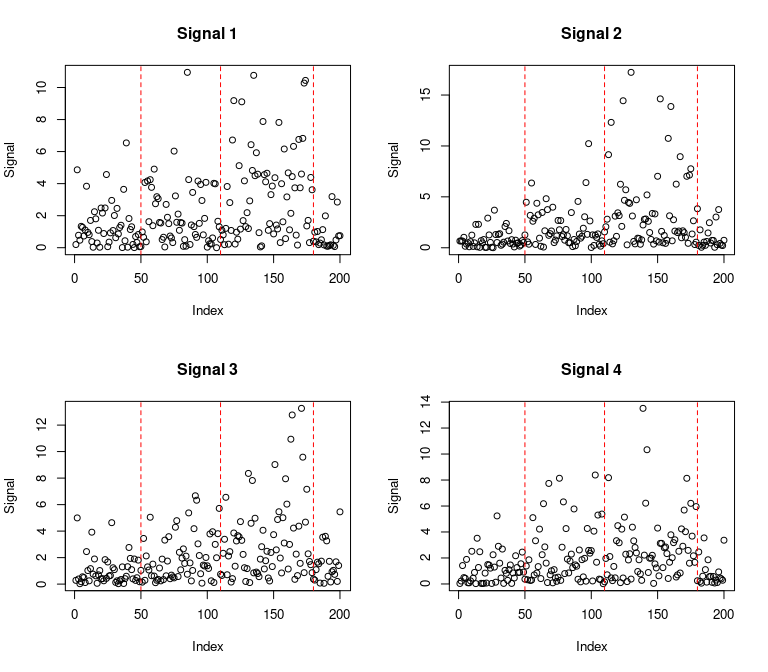

### Fitting the model

Now that we have a data set, we fit the model using the `fit_blockcpd` function. The user can choose fitting method, statistical family, maximum number of blocks and provide his own penalization function.

Two fitting methods are currently implemented: “hierseg” and “dynseg”. The first is a fast greedy implementation of the hierarchical segmentation (also called binary segmentation), and the second is dynamic segmentation, an exact but slower implementation using dynamic programming. The statistical methods are the same as discussed in the simulations.

We will better discuss the penalization constant and maximum blocks in the next section.

Lets fit the model using “hierseg” (default), the “exponential” family, penalization constant equals 1.73 and default penalization.

```r
  seg_model = fit_blockcpd(sim_df$data_matrix, family = "exponential",
                           lambda = 1.73)
```

The return object is a S3 class called `blockcpd`. It contains the estimated change-points, parameters, loss, negative log likelihood and metadata. It also contains bootstrap information if the bootstrap flag is `TRUE`. We will see why running the model with bootstrap can be useful for the practitioner.

The user can plot how a parameter varies with the indices just by calling `plot` and passing the model as an argument.

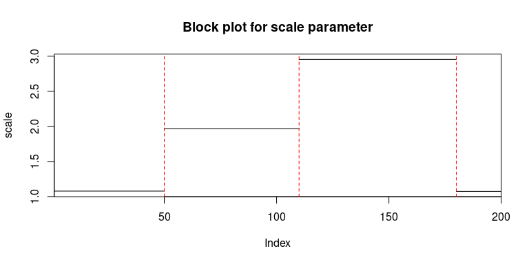

```r
  plot(seg_model, parameter = "scale")
```

The flat regions corresponds to variables grouped in the same block. The height of the block corresponds to the estimated value of the parameter for that block. The vertical lines shows where the model detected a change-point. In this example, it detected the changes at (50,110,180), which are the also true change-points.

Since the scale parameter is associated with the expected value of the variables for the exponential distribution, we could plot a “average signal” along with the block plot, as show in the figure below.

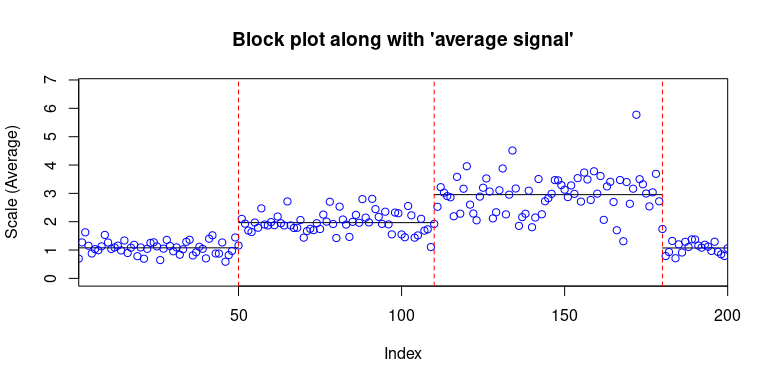

The black lines are the estimated scale (average value) parameter for the blocks, and the blue points are the average signal for each index.

### Avoiding over-segmentation

In order to avoid over segmentation, two parameters can be used: the penalization constant (the `lambda` argument in `fit_blockcpd`) and the maximum number of blocks (the `max_blocks` argument).

If we used a very small value for the penalization constant, we would have detected many blocks, reaching a over-segmentation! However, we only know it would have been a over-segmentation because we simulated the data. We need an data-driven approach to select lambda.

The constant has to be chosen carefully. A common approach is to use an adaptation of the elbow plot heuristics. A graphic of how the number of detect blocks varies with the penalization constant lambda is constructed, and then we try to visually select a value in which the curve “flats out” after it.

The package provides the `select_frv` function. The first function uses a methodology similar to the described above in order to observe how the estimated number of change-points vary with the penalization constant. The main advantage is that it provides an automatic suggestion for the best regularization constant, number of change-points and model. Optionally, the user can call the `plot` function on its output in order to do graphical inspection.

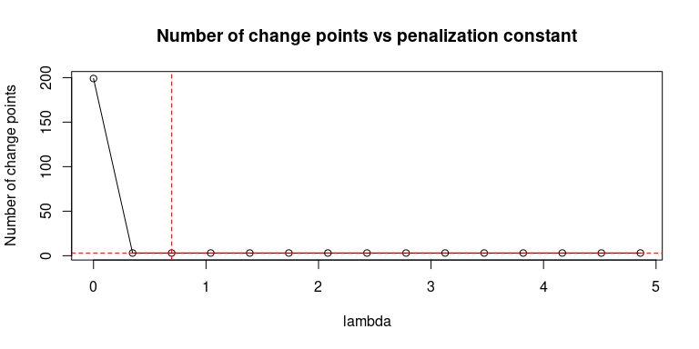

```r
  model_args = list(family = "exponential") # do not include lambda!

  # search space for lambda
  lambda_left = 0
  lambda_right = 5
  step = "automatic" # can also be set to any numeric value

  # uses the data and passed arguments to fit the curve and suggested values
  frv = select_frv(sim_df$data_matrix, lambda_left = lambda_left, step = step,
                   lambda_right = lambda_right,
                   model_args = model_args)

  # plots the curve if the user prefers to perform graphical inspection
  plot(frv)
```

Another way to control over-segmentation is using the `max_blocks` argument. When working with a large number of variables, if there is no justification for a your signal to have a large number of blocks, try setting small values for `max_blocks`. This will also make `fit_blockcpd` run much faster.

### Is that change spurious? Check it with Confidence Plot

A central question in statistics is: how confident are you on the fitted model? How do you know the results you obtained are not spurious, that is, they are not due to chance?

If you are a practitioner and your experience suggests that your signals have a structural break at given location, it is not enough to fit a model and detect a change at the location; you have to argue that, if you repeated the experiment, you would consistently detect a change at that location. This is the core of scientific inquiry.

To that end, we introduce the confidence plot. It plots the estimates of how likely it is for the model to detect a change at any given point. True structural breaks should have confidence near 100%, while non-break indices should have a confidence near 0%. It might also be difficult to detect a true change-point at the given sample size. In this case, it should fluctuate in the middle.

The confidence is computed using bootstrap re-sampling. To create the plot, we first need to refit the model passing the `TRUE` value to the `bootstrap` argument. Then, we call the `confidence_plot` passing the fitted model.

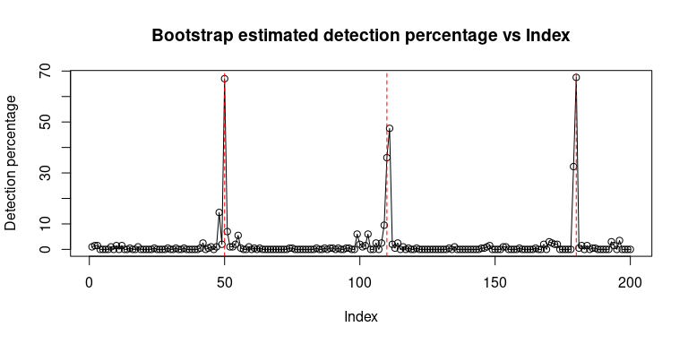

```r
  seg_model = fit_blockcpd(sim_df$data_matrix, family = "exponential",
                           lambda = frv$suggested_lambda,
                           bootstrap = TRUE, bootstrap_samples = 200L)
  confidence_plot(seg_model, scale = "percentage")
```

The plot shows the detection percentage of each index as a change-point. The dashed vertical red lines shows the location of the final detected change-points.

In this example, it is strongly suggested that 50 and 180 are true change-points, but 110 also has a high detection value near 50%. Other indices have somewhat low detection rates, suggesting that we indeed only have 3 change-points. Notice that this plot can also aid us in deciding if a given region has a change-point.

### Recommendation for datasets with large number of variables

To reduce run-time on large datasets, we recommend using the `hierseg` method when using `fit_blockcpd` and `select_frv`. It is also advisable to set small values for `max_blocks`, not only for time issues but also to avoid over-segmentation.

A final observation is that fitting the model with the `bootstrap` as `TRUE` is computationally expensive, so avoid using very large values for `bootstrap_samples`.

### Reference

This package is an implementation of the method and heuristics discussed in the [paper](https://arxiv.org/abs/2111.10187), currently available as a pre-print. For citation purposes, see the reference below.

Prates, L., Lemes, R. B., Hünemeier, T., & Leonardi, F. (2021). Population based change-point detection for the identification of homozygosity islands. arXiv preprint arXiv:2111.10187.